# Signature Violin Plots

Jessica Scarborough

8/13/2020

# Set up and Load Data

First, we’re going to load our dataset, which includes a list of 13 genes (the Cisplatin Sensitivity Signature) and TCGA expression data for many types of epithelial-based cancers. Let’s take a look at our signature. If you wish to perform the analysis yourself, you may uncomment the line manually loading the signature.

```r
cisplatin_sens_sig <- readRDS(here("Cisplatin_Signature.rds"))

print(cisplatin_sens_sig)
```

```
##  [1] "100"   "10360" "1475"  "3852"  "3861"  "483"   "54742" "57478" "646"
## [10] "79649" "84230" "84529" "91607"
```

We’re going to load all cancer subtypes separately, adding tissue labels (`tissue` and `tcga_label`) that we’ll utilize later. If you wish to perform these analyses yourself, the data can be found [here](https://drive.google.com/file/d/1kxYgym_VWwZhcKuxdEGB50MYBkM1FpHT/view?usp=sharing). Unzip the file so that each `.txt` file is found in a directory `TCGA_Data`.

```r
tcga_BLCA <- data.frame(t(read.table("../TCGA_Data/cleaned_BLCA_mRNA.txt", header = TRUE, stringsAsFactors = FALSE)), check.names = FALSE)
tcga_BLCA$tcga_label <- rep("BLCA", nrow(tcga_BLCA))
tcga_BLCA$tissue <- rep("Bladder", nrow(tcga_BLCA))
tcga_BRCA <- data.frame(t(read.table("../TCGA_Data/cleaned_BRCA_mRNA.txt", header = TRUE, stringsAsFactors = FALSE)), check.names = FALSE)
tcga_BRCA$tcga_label <- rep("BRCA", nrow(tcga_BRCA))
tcga_BRCA$tissue <- rep("Breast", nrow(tcga_BRCA))
tcga_CESC <- data.frame(t(read.table("../TCGA_Data/cleaned_CESC_mRNA.txt", header = TRUE, stringsAsFactors = FALSE)), check.names = FALSE)
tcga_CESC$tcga_label <- rep("CESC", nrow(tcga_CESC))
tcga_CESC$tissue <- rep("Cervix", nrow(tcga_CESC))
tcga_COAD <- data.frame(t(read.table("../TCGA_Data/cleaned_COAD_mRNA.txt", header = TRUE, stringsAsFactors = FALSE)), check.names = FALSE)
tcga_COAD$tcga_label <- rep("COAD", nrow(tcga_COAD))
tcga_COAD$tissue <- rep("Colon", nrow(tcga_COAD))
tcga_HNSC <- data.frame(t(read.table("../TCGA_Data/cleaned_HNSC_mRNA.txt", header = TRUE, stringsAsFactors = FALSE)), check.names = FALSE)
tcga_HNSC$tcga_label <- rep("HNSC", nrow(tcga_HNSC))
tcga_HNSC$tissue <- rep("Head and Neck", nrow(tcga_HNSC))
tcga_KIRC <- data.frame(t(read.table("../TCGA_Data/cleaned_KIRC_mRNA.txt", header = TRUE, stringsAsFactors = FALSE)), check.names = FALSE)
tcga_KIRC$tcga_label <- rep("KIRC", nrow(tcga_KIRC))
tcga_KIRC$tissue <- rep("Kidney Clear Cell", nrow(tcga_KIRC))
tcga_KIRP <- data.frame(t(read.table("../TCGA_Data/cleaned_KIRP_mRNA.txt", header = TRUE, stringsAsFactors = FALSE)), check.names = FALSE)
tcga_KIRP$tcga_label <- rep("KIRP", nrow(tcga_KIRP))
tcga_KIRP$tissue <- rep("Kidney Papillary", nrow(tcga_KIRP))
tcga_LIHC <- data.frame(t(read.table("../TCGA_Data/cleaned_LIHC_mRNA.txt", header = TRUE, stringsAsFactors = FALSE)), check.names = FALSE)
tcga_LIHC$tcga_label <- rep("LIHC", nrow(tcga_LIHC))
tcga_LIHC$tissue <- rep("Liver HCC", nrow(tcga_LIHC))
tcga_LUAD <- data.frame(t(read.table("../TCGA_Data/cleaned_LUAD_mRNA.txt", header = TRUE, stringsAsFactors = FALSE)), check.names = FALSE)
tcga_LUAD$tcga_label <- rep("LUAD", nrow(tcga_LUAD))
tcga_LUAD$tissue <- rep("Lung Adenocarcinoma", nrow(tcga_LUAD))
tcga_LUSC <- data.frame(t(read.table("../TCGA_Data/cleaned_LUSC_mRNA.txt", header = TRUE, stringsAsFactors = FALSE)), check.names = FALSE)
tcga_LUSC$tcga_label <- rep("LUSC", nrow(tcga_LUSC))
tcga_LUSC$tissue <- rep("Lung SCC", nrow(tcga_LUSC))
tcga_OV <-   data.frame(t(read.table("../TCGA_Data/cleaned_OV_mRNA.txt", header = TRUE, stringsAsFactors = FALSE)), check.names = FALSE)
tcga_OV$tcga_label <- rep("OV", nrow(tcga_OV))
tcga_OV$tissue <- rep("Ovary", nrow(tcga_OV))
tcga_PAAD <- data.frame(t(read.table("../TCGA_Data/cleaned_PAAD_mRNA.txt", header = TRUE, stringsAsFactors = FALSE)), check.names = FALSE)
tcga_PAAD$tcga_label <- rep("PAAD", nrow(tcga_PAAD))
tcga_PAAD$tissue <- rep("Pancreas", nrow(tcga_PAAD))
tcga_PRAD <- data.frame(t(read.table("../TCGA_Data/cleaned_PRAD_mRNA.txt", header = TRUE, stringsAsFactors = FALSE)), check.names = FALSE)
tcga_PRAD$tcga_label <- rep("PRAD", nrow(tcga_PRAD))
tcga_PRAD$tissue <- rep("Prostate", nrow(tcga_PRAD))
tcga_STAD <- data.frame(t(read.table("../TCGA_Data/cleaned_STAD_mRNA.txt", header = TRUE, stringsAsFactors = FALSE)), check.names = FALSE)
tcga_STAD$tcga_label <- rep("STAD", nrow(tcga_STAD))
tcga_STAD$tissue <- rep("Stomach", nrow(tcga_STAD))
tcga_THCA <- data.frame(t(read.table("../TCGA_Data/cleaned_THCA_mRNA.txt", header = TRUE, stringsAsFactors = FALSE)), check.names = FALSE)
tcga_THCA$tcga_label <- rep("THCA", nrow(tcga_THCA))
tcga_THCA$tissue <- rep("Thymus", nrow(tcga_THCA))
tcga_UCEC <- data.frame(t(read.table("../TCGA_Data/cleaned_UCEC_mRNA.txt", header = TRUE, stringsAsFactors = FALSE)), check.names = FALSE)
tcga_UCEC$tcga_label <- rep("UCEC", nrow(tcga_UCEC))
tcga_UCEC$tissue <- rep("Uterus", nrow(tcga_UCEC))
```

# Data Pre-Processing

## Format Dataframe

Here, we’re combining all the TCGA samples into a single dataframe, with a column to label their histology in the data frame `epi_tcga`. Then, we’ll create a new dataframe that contains just 13 columns, containing the gene expression for all TCGA samples, `epi_tcga_cis_sig`.

```r
epi_tcga <- bind_rows(tcga_BLCA, tcga_BRCA, tcga_CESC, tcga_COAD, tcga_HNSC,
                      tcga_KIRC, tcga_KIRP, tcga_LIHC, tcga_LUAD,
                      tcga_LUSC, tcga_OV, tcga_PAAD, tcga_PRAD, tcga_STAD,
                      tcga_THCA, tcga_UCEC)

epi_tcga_cis_sig <- epi_tcga %>%
  select(all_of(cisplatin_sens_sig))
```

Let’s take a look at our data structure now.

```r
head(epi_tcga_cis_sig)
```

```
##                    100    10360      1475       3852       3861      483
## TCGA.2F.A9KO  534.1108 517.7843  211.0787  4826.2391  6204.6647 2258.309
## TCGA.2F.A9KP 1181.4399 823.9700  375.7803  1787.3491   260.9238 2334.582
## TCGA.2F.A9KQ  154.8447 349.0960 1484.4692    34.3069   630.9689 4886.880
## TCGA.2F.A9KR  356.6226 334.7789 6894.5458 58749.1853  3633.6569 6390.716
## TCGA.2F.A9KT 2748.4454 848.5020 4171.2832  9480.4975 23262.8604 2646.128
## TCGA.2F.A9KW  218.3475 754.0057   85.3493    71.2116    19.8974 4358.572
##                 54742     57478     646    79649    84230    84529    91607
## TCGA.2F.A9KO 503.2070 3198.2507  2.3324 122.4490 321.8659 495.0437 389.5044
## TCGA.2F.A9KP 250.5202 1812.3179  0.8323 119.0179 176.8623 523.0961  70.7449
## TCGA.2F.A9KQ 213.2592  785.3500  0.0000  20.3987 390.8206 394.5294  94.1122
## TCGA.2F.A9KR 395.0866 1067.0187 50.8104  96.8722 159.0793 292.9909 197.0684
## TCGA.2F.A9KT 517.2414  858.1119  2.2612  79.1408 124.9293 543.8101  79.7060
## TCGA.2F.A9KW  15.7085  381.1917  1.5708 375.9556 399.5183 204.7335 360.7708
```

## Scale and Extract Scores

Next, we’re going to scale the data, creating simple z-scores using the `scale` function on each gene. This process removes the row names, so we’ll add them back. Again, let’s look at our dataset.

```r
epi_tcga_cis_sig <- data.frame(scale(epi_tcga_cis_sig, center = TRUE, scale = TRUE))
row.names(epi_tcga_cis_sig) <- row.names(epi_tcga)

head(epi_tcga_cis_sig)
```

```
##                    X100      X10360       X1475       X3852      X3861
## TCGA.2F.A9KO  0.7374454  0.01360845 -0.25936495 -0.34019017 -0.1988289
## TCGA.2F.A9KP  2.5587778  0.70037164 -0.23229048 -0.36429885 -0.2331945
## TCGA.2F.A9KQ -0.3296619 -0.36475315 -0.05003864 -0.37820641 -0.2310549
## TCGA.2F.A9KR  0.2380627 -0.39686588  0.83929687  0.08760125 -0.2136940
## TCGA.2F.A9KT  6.9677218  0.75539601  0.39163331 -0.30326615 -0.1002016
## TCGA.2F.A9KW -0.1509897  0.54344430 -0.28003298 -0.37791363 -0.2345880
##                    X483      X54742     X57478       X646     X79649
## TCGA.2F.A9KO -0.3095516  0.24530652  5.5847504 -0.3787681 -0.5864437
## TCGA.2F.A9KP -0.2919355 -0.10712836  2.5421191 -0.3802617 -0.6053151
## TCGA.2F.A9KQ  0.2975480 -0.15909813  0.2875475 -0.3810904 -1.1477298
## TCGA.2F.A9KR  0.6448766  0.09450561  0.9059137 -0.3305006 -0.7271185
## TCGA.2F.A9KT -0.2199803  0.26488100  0.4472866 -0.3788390 -0.8246428
## TCGA.2F.A9KW  0.1755289 -0.43463194 -0.5997284 -0.3795264  0.8078661
##                   X84230    X84529     X91607
## TCGA.2F.A9KO -0.31396614 2.1777129 -0.5252614
## TCGA.2F.A9KP -0.71517107 2.3717875 -1.0183167
## TCGA.2F.A9KQ -0.12317801 1.4823262 -0.9821723
## TCGA.2F.A9KR -0.76437417 0.7798538 -0.8229202
## TCGA.2F.A9KT -0.85886251 2.5150928 -1.0044557
## TCGA.2F.A9KW -0.09911268 0.1692638 -0.5697063
```

Next, let’s get get a score for each sample’s expression of the Cisplatin Sensivitiy Signature. First, we’ll take the median expression of each sample (row), using the `apply` function. Once this is done, we can add back in the `tissue` and `tcga_label` columns. We’ll check out what the dataframe looks like now.

```r
epi_tcga_cis_sig$median_expr <- apply(epi_tcga_cis_sig, 1, median)
epi_tcga_cis_sig$tissue <- epi_tcga$tissue
epi_tcga_cis_sig$tcga_label <- epi_tcga$tcga_label

head(epi_tcga_cis_sig)
```

```
##                    X100      X10360       X1475       X3852      X3861
## TCGA.2F.A9KO  0.7374454  0.01360845 -0.25936495 -0.34019017 -0.1988289
## TCGA.2F.A9KP  2.5587778  0.70037164 -0.23229048 -0.36429885 -0.2331945
## TCGA.2F.A9KQ -0.3296619 -0.36475315 -0.05003864 -0.37820641 -0.2310549
## TCGA.2F.A9KR  0.2380627 -0.39686588  0.83929687  0.08760125 -0.2136940
## TCGA.2F.A9KT  6.9677218  0.75539601  0.39163331 -0.30326615 -0.1002016
## TCGA.2F.A9KW -0.1509897  0.54344430 -0.28003298 -0.37791363 -0.2345880
##                    X483      X54742     X57478       X646     X79649
## TCGA.2F.A9KO -0.3095516  0.24530652  5.5847504 -0.3787681 -0.5864437
## TCGA.2F.A9KP -0.2919355 -0.10712836  2.5421191 -0.3802617 -0.6053151
## TCGA.2F.A9KQ  0.2975480 -0.15909813  0.2875475 -0.3810904 -1.1477298
## TCGA.2F.A9KR  0.6448766  0.09450561  0.9059137 -0.3305006 -0.7271185
## TCGA.2F.A9KT -0.2199803  0.26488100  0.4472866 -0.3788390 -0.8246428
## TCGA.2F.A9KW  0.1755289 -0.43463194 -0.5997284 -0.3795264  0.8078661
##                   X84230    X84529     X91607 median_expr  tissue tcga_label
## TCGA.2F.A9KO -0.31396614 2.1777129 -0.5252614 -0.25936495 Bladder       BLCA
## TCGA.2F.A9KP -0.71517107 2.3717875 -1.0183167 -0.23319448 Bladder       BLCA
## TCGA.2F.A9KQ -0.12317801 1.4823262 -0.9821723 -0.23105495 Bladder       BLCA
## TCGA.2F.A9KR -0.76437417 0.7798538 -0.8229202  0.08760125 Bladder       BLCA
## TCGA.2F.A9KT -0.85886251 2.5150928 -1.0044557 -0.10020161 Bladder       BLCA
## TCGA.2F.A9KW -0.09911268 0.1692638 -0.5697063 -0.23458805 Bladder       BLCA
```

Now, we need to start formatting these dataframes with the final product in mind. We want a violin plot that ranks the groups in order. For this, we’ll say we want them ranked by median value of the entire group. We’ll extract these median group values, then convert the `tcga_label` and `tissue` variables to ordered factors. `ggplot2` will recognize these orders and automatically apply them when plotting. In addition to this, we’ll find the number of samples in each group, which will be used later in plotting.

```r
median_epi_group <- epi_tcga_cis_sig %>%
  group_by(tcga_label, tissue) %>%
  summarize(median = median(median_expr), n = n()) %>%
  arrange(desc(median))
median_epi_group <- median_epi_group %>%
  # ungroup(n) %>%
  # ungroup(tcga_label) %>%
  # ungroup(tissue) %>%
  mutate(tcga_label = fct_reorder(tcga_label, desc(median))) %>%
  mutate(tissue = fct_reorder(tissue, desc(median)))



epi_tcga_cis_sig$tcga_label <- factor(epi_tcga_cis_sig$tcga_label,
                                      ordered = TRUE,
                                      levels = median_epi_group$tcga_label)
epi_tcga_cis_sig$tissue <- factor(epi_tcga_cis_sig$tissue,
                                      ordered = TRUE,
                                      levels = median_epi_group$tissue)

# tcga_tcga_label_count <- epi_tcga_cis_sig %>% count(tcga_label)
# tcga_tissue_count <- epi_tcga_cis_sig %>% count(tissue)

saveRDS(epi_tcga, "../TCGA_Data/epi_tcga.RDS")
epi_tcga <- readRDS("../TCGA_Data/epi_tcga.RDS")
saveRDS(epi_tcga_cis_sig, "../TCGA_Data/epi_tcga_cisplatin_sig.RDS")
epi_tcga_cis_sig <- readRDS("../TCGA_Data/epi_tcga_cisplatin_sig.RDS")
```

Finally, we need to plot these scores on a log-scale axis. This means that we can’t have any negative or 0 values. We’ll make a new dataframe, called `viol_data` with linearly scaled scores. Here, we simply add the minimum value to all the scores and 1. This means that the scores will start at a minimum of 1. We’ll confirm that that’s the case and take a final look at our dataset before plotting.

```r
viol_data <- epi_tcga_cis_sig
viol_data$median_expr <- epi_tcga_cis_sig$median_expr + (abs(min(epi_tcga_cis_sig$median_expr))+1)

min(viol_data$median_expr)
```

```
## [1] 1
```

```r
head(viol_data)
```

```
##                    X100      X10360       X1475       X3852      X3861
## TCGA.2F.A9KO  0.7374454  0.01360845 -0.25936495 -0.34019017 -0.1988289
## TCGA.2F.A9KP  2.5587778  0.70037164 -0.23229048 -0.36429885 -0.2331945
## TCGA.2F.A9KQ -0.3296619 -0.36475315 -0.05003864 -0.37820641 -0.2310549
## TCGA.2F.A9KR  0.2380627 -0.39686588  0.83929687  0.08760125 -0.2136940
## TCGA.2F.A9KT  6.9677218  0.75539601  0.39163331 -0.30326615 -0.1002016
## TCGA.2F.A9KW -0.1509897  0.54344430 -0.28003298 -0.37791363 -0.2345880
##                    X483      X54742     X57478       X646     X79649
## TCGA.2F.A9KO -0.3095516  0.24530652  5.5847504 -0.3787681 -0.5864437
## TCGA.2F.A9KP -0.2919355 -0.10712836  2.5421191 -0.3802617 -0.6053151
## TCGA.2F.A9KQ  0.2975480 -0.15909813  0.2875475 -0.3810904 -1.1477298
## TCGA.2F.A9KR  0.6448766  0.09450561  0.9059137 -0.3305006 -0.7271185
## TCGA.2F.A9KT -0.2199803  0.26488100  0.4472866 -0.3788390 -0.8246428
## TCGA.2F.A9KW  0.1755289 -0.43463194 -0.5997284 -0.3795264  0.8078661
##                   X84230    X84529     X91607 median_expr  tissue tcga_label
## TCGA.2F.A9KO -0.31396614 2.1777129 -0.5252614    1.449899 Bladder       BLCA
## TCGA.2F.A9KP -0.71517107 2.3717875 -1.0183167    1.476070 Bladder       BLCA
## TCGA.2F.A9KQ -0.12317801 1.4823262 -0.9821723    1.478209 Bladder       BLCA
## TCGA.2F.A9KR -0.76437417 0.7798538 -0.8229202    1.796865 Bladder       BLCA
## TCGA.2F.A9KT -0.85886251 2.5150928 -1.0044557    1.609063 Bladder       BLCA
## TCGA.2F.A9KW -0.09911268 0.1692638 -0.5697063    1.474676 Bladder       BLCA
```

# Create Violin Plots

We’ll use `viol_data` to plot our ordered violin plots. This function requires a dataframe that contains a column with the signature scores (`median_expr`) and a column labeling each sample’s histology. Here, that’s `tcga_label` and below we use `tissue`. The colors are simply for aesthetics, labeling by each subgroup. Finally, we use a second (`median_epi_group`) dataframe containing some summarized characteristics for each label. We label each violin plot with the total number of samples (`n`) in each group.

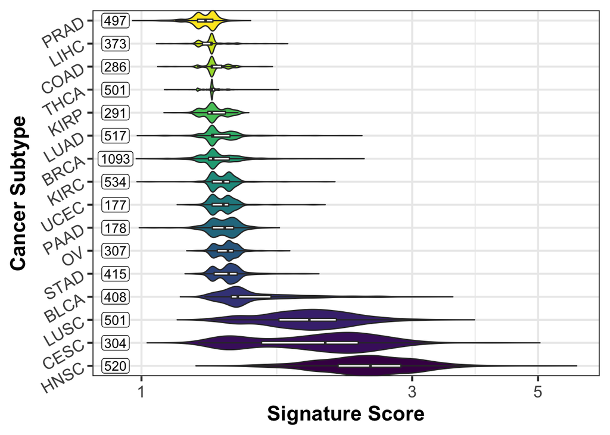

```r
ggplot(viol_data, aes(x = tcga_label, y=median_expr)) +
  geom_violin(trim = FALSE, scale = "width", aes(fill=tissue)) +
  geom_boxplot(width = 0.12, outlier.shape = NA) +
  scale_y_continuous(trans="log10") +
  scale_x_discrete(expand = c(0,0)) +
  geom_label(aes(x = tcga_label, y = .9, label = n), data = median_epi_group,
             label.padding = unit(0.15, "lines")) +
  coord_flip() +
  ylab("Signature Score") + xlab("Cancer Subtype") +
  theme_bw(base_size = 17) +
  theme(axis.text.y = element_text(angle = 30),
    axis.title=element_text(face="bold"),
        legend.position = "none")
```

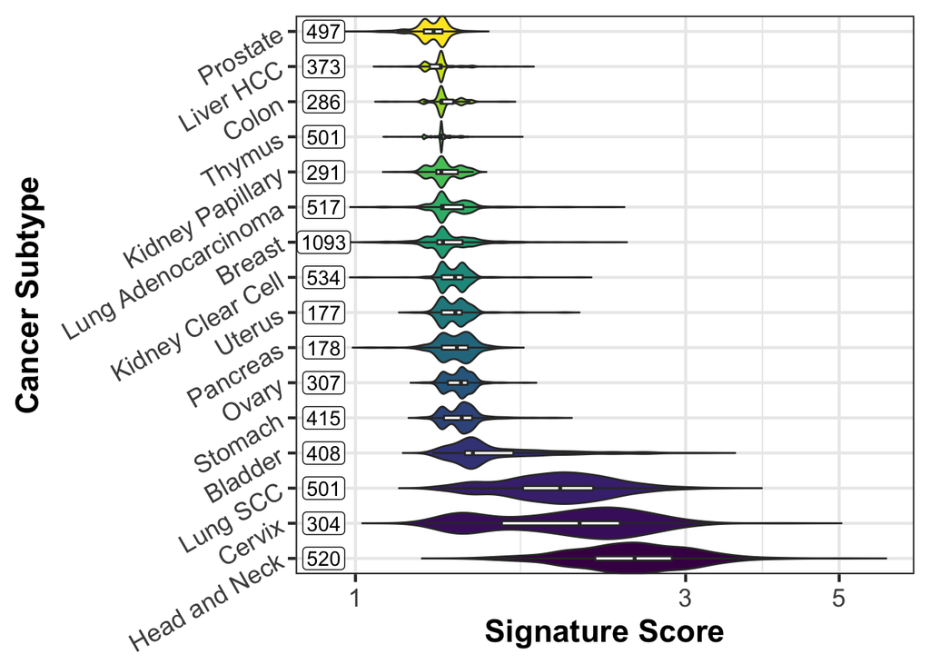

```r
ggplot(viol_data, aes(x = tissue, y=median_expr)) +
  geom_violin(trim = FALSE, scale = "width", aes(fill=tissue)) +
  geom_boxplot(width = 0.12, outlier.shape = NA) +
  scale_y_continuous(trans="log10") +
  scale_x_discrete(expand = c(0,0)) +
  geom_label(aes(x = tissue, y = .9, label = n), data = median_epi_group,
             label.padding = unit(0.15, "lines")) +
  coord_flip() +
  ylab("Signature Score") + xlab("Cancer Subtype") +
  theme_bw(base_size = 17) +
  theme(axis.text.y = element_text(angle = 30),
    axis.title=element_text(face="bold"),
        legend.position = "none")
```